# Aides Drug

Glen Abram

10/30/2019

# Introduction

A new preventative aides (abacavirinol) is under test in clinical trials. Analyze the effectiveness of this drug across the board. Consider population subgroups by gender, drug use, and sexual orientation. We will conduct an evaluation of drug efficacy for everyone.We will then conduct an evaluation of drug efficacy for females only.Thirdly, we will conduct an evaluation of drug efficacy for males only.Moreover, we will execute an evaluation of drug efficacy for only drug users. Finally, an evaluation of drug efficacy for only LBGTQ.

# Methods

## Question 1: Is the vaccine effective for the population?

$H_0$ The vaccine has no effect on whether one contracts aids or not $H_1$ The vaccine affects whether one contracts aids or not

This barchart depicts aids patients that consumed the placebo had a higher percentage than those that consumed the drug. Nonetheless, People without the virus were close in percentages.

```r
allPeople = xtabs(~infected + treatment, data = avast)
rowPerc(allPeople)
```

```
##         treatment
## infected   drug placebo  Total
##     aids  40.87   59.13 100.00
##     none  49.10   50.90 100.00
```

```r
chisqtestGC(allPeople,data=avast)
```

```
## Pearson's Chi-squared test with Yates' continuity correction
##
## Observed Counts:
##         treatment
## infected  drug placebo
##     aids   423     612
##     none 10168   10540
##
## Counts Expected by Null:
##         treatment
## infected     drug  placebo
##     aids   504.15   530.85
##     none 10086.85 10621.15
##
## Contributions to the chi-square statistic:
##         treatment
## infected  drug placebo
##     aids 13.06   12.40
##     none  0.65    0.62
##
##
## Chi-Square Statistic = 26.4104
## Degrees of Freedom of the table = 1
## P-Value = 0
```

This table shows the p value is 0 which is less than 0.05. Therefore we reject the null hypothesis. It shows that the drug is more effective than the placebo.

# Results

## Descriptive Results

### Graphical Descriptive Results

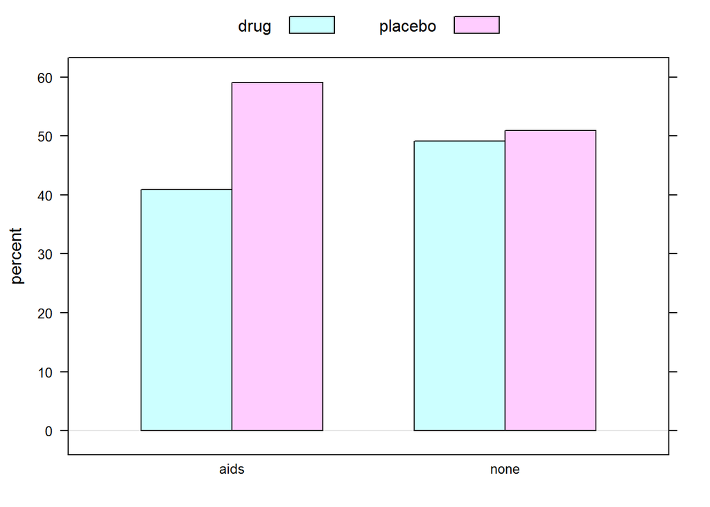

```r
barchartGC(~infected + treatment, data = avast,type='percent')
```

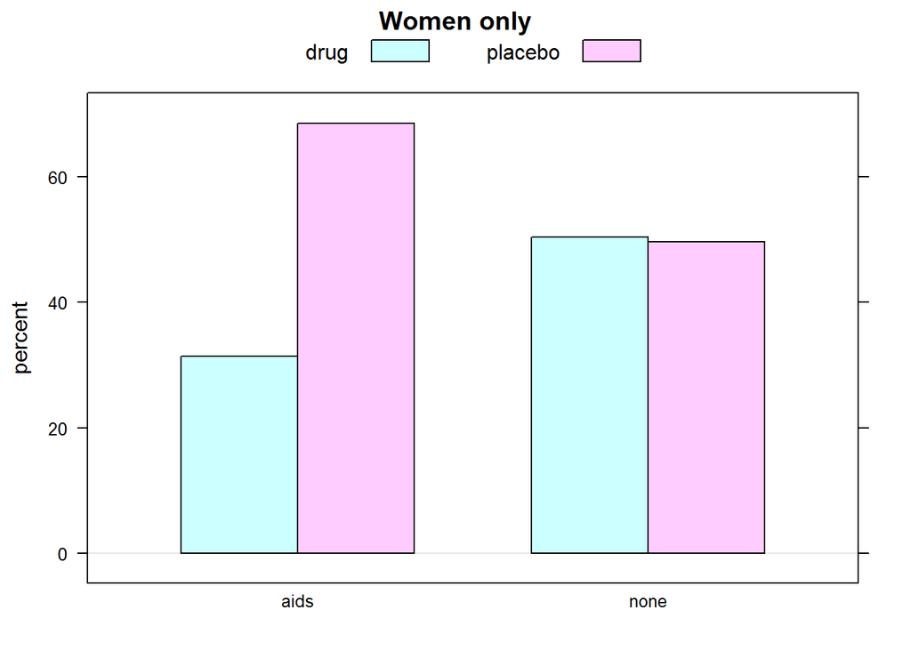

```r
barchartGC(~infected + treatment, data = filter(avast, sex == 'gal') , main='Women only', type='percent')
```

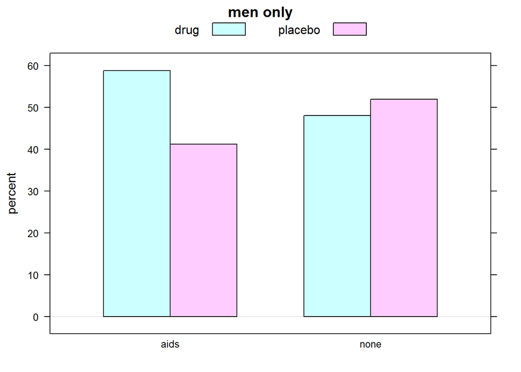

```r
barchartGC(~infected + treatment, data = filter(avast, sex == 'guy') , main='men only', type='percent')
```

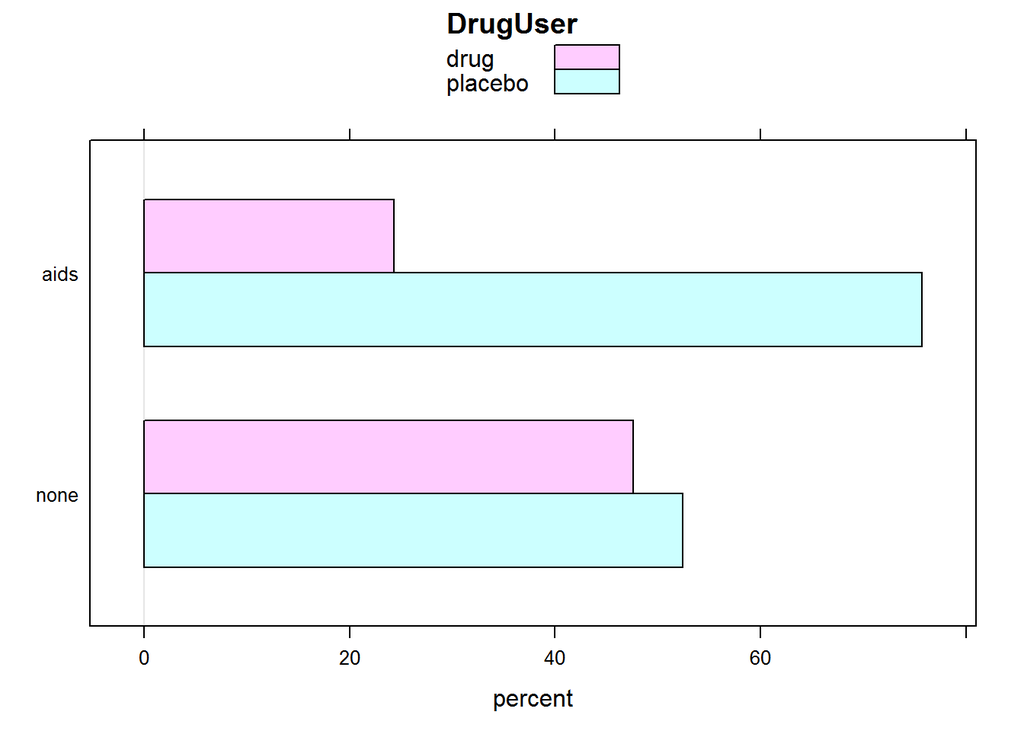

```r
barchartGC(~ infected+treatment, , main = 'DrugUser', type ='percent', data=filter(avast, DrugUser == 'yes'), horizontal = TRUE)
```

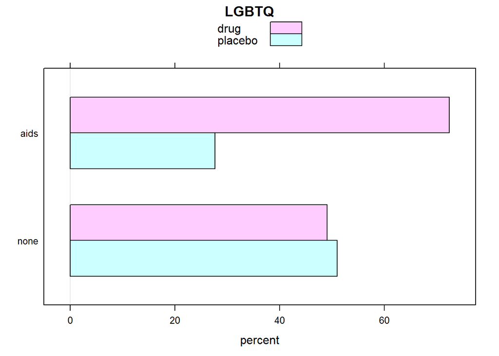

```r
barchartGC(~ infected+treatment, , main = 'LGBTQ', type ='percent', data=filter(avast, LGBTQ == 'gay'), horizontal = TRUE)
```

### Numerical Descriptive Results

## Inferential Results

```r
tab1 = xtabs (~infected+treatment, data=filter(avast))
rowPerc(tab1)
```

```
##         treatment
## infected   drug placebo  Total
##     aids  40.87   59.13 100.00
##     none  49.10   50.90 100.00
```

```r
tab2 = xtabs (~infected+treatment, data=filter(avast,sex== 'gal' ))
rowPerc(tab2)
```

```
##         treatment
## infected   drug placebo  Total
##     aids  31.42   68.58 100.00
##     none  50.38   49.62 100.00
```

```r
tab3 = xtabs (~infected+treatment,data=filter(avast,sex== 'guy' ))
rowPerc(tab3)
```

```
##         treatment
## infected   drug placebo  Total
##     aids  58.82   41.18 100.00
##     none  48.06   51.94 100.00
```

```r
tab4 = xtabs (~infected+treatment,data=filter(avast,DrugUser== 'yes' ))
rowPerc(tab4)
```

```
##         treatment
## infected   drug placebo  Total
##     aids  24.29   75.71 100.00
##     none  47.59   52.41 100.00
```

```r
tab5 = xtabs (~infected+treatment,data=filter(avast,LGBTQ== 'gay' ))
rowPerc(tab5)
```

```
##         treatment
## infected   drug placebo  Total
##     aids  72.38   27.62 100.00
##     none  49.05   50.95 100.00
```

# Discussion and Conclusion